# Project 3

## Biomarker Identification of oncogene dependency

### Background

Goal: identify cancer indications likely to predict responses to therapy targeting important genes, using the ERBB3/Her3 gene as an example

Datasets provided:

- **CRISPRGeneEffect.csv**: Gene effect estimates for all models. A lower score means that a gene is more likely to be dependent in a cell line.
- **OmicsCNGene.csv:** Gene-level copy number data that is log2 transformed with a pseudo-count of 1; log2(CN ratio + 1).
- **OmicsExpressionProteinCodingGenesTPMLogp1.csv:** Gene expression TPM values of the protein coding genes for DepMap cell lines.
- **Model.csv:** Metadata describing all cancer models/cell lines which are referenced by a dataset contained within the DepMap portal.

### Approach

#### Set working directory and import datasets provided

```r
#set working directory
setwd("C:/Users/user/Project3")

#import csv files
crisprgeneeffect<-read.csv("CRISPRGeneEffect.csv",header=TRUE)
omicscngene<-read.csv("OmicsCNGene.csv",header=TRUE)
omicsexppcg<-read.csv("OmicsExpressionProteinCodingGenesTPMLogp1.csv",header=TRUE)
model<-read.csv("Model.csv",header=TRUE)
```

#### Check duplicates

```r
sum(duplicated(crisprgeneeffect$ModelID))
sum(duplicated(omicscngene$X))
sum(duplicated(omicsexppcg$X))
```

#### Visualize distribution of ERBB3/HER3 gene effect

Note: A score of 0 is equivalent to a gene that is not essential whereas a score of -1 corresponds to the median of all common essential genes.

```r
#find median of ERBB3 expression
ERBB3med<-median(crisprgeneeffect$ERBB3..2065.)

#Quantiles of ERBB3 expression
quantiles <- quantile(crisprgeneeffect[["ERBB3..2065."]], probs = c(0.25, 0.75))

#density plot to visualize the ERBB3 gene effect on all cell lines
library(tidyverse)
library(ggplot2)
crisprgeneeffect%>%ggplot(aes(x=ERBB3..2065.)) +geom_density()+ geom_vline(xintercept=ERBB3med,col='red')

Q1 <- quantile(crisprgeneeffect$ERBB3..2065., probs = 0.25)
Q3 <- quantile(crisprgeneeffect$ERBB3..2065., probs = 0.75)

#include quantile in the plot
ggplot(crisprgeneeffect, aes(x = ERBB3..2065.)) +
  geom_density() +
  geom_vline(xintercept = Q1, linetype = "dashed", color = "red", size = 1) +
  geom_vline(xintercept = Q3, linetype = "dashed", color = "red", size = 1) +
  geom_vline(xintercept = ERBB3med, linetype = "dashed", color = "blue", size = 1) +
  labs(title = "Density Plot with Q1, Q3, and Median Lines")
```

[output not shown]

#### Obtain cn and pcg data with known HER3 gene effect for downstream analysis

```r
#clean omics datasets to obtain 1095 cell lines only (with known HER3 gene effect)
finalcelllinesv<-crisprgeneeffect$ModelID
omicscngene_clean<-omicscngene[omicscngene$X %in% finalcelllinesv, ]
omicsexppcg_clean<-omicsexppcg[omicsexppcg$X %in% finalcelllinesv, ]
```

#### Classify the cell lines according to Q1 and Q3

```r
#classify the cell lines into two groups
Q1 <- quantile(crisprgeneeffect$ERBB3..2065., probs = 0.25)
Q3 <- quantile(crisprgeneeffect$ERBB3..2065., probs = 0.75)
crisprgeneeffectclass<-crisprgeneeffect%>%mutate(explevel=case_when(ERBB3..2065.<=Q1 ~ 'highdep',ERBB3..2065.>=Q3 ~ 'nodep'))

#summarize high and low classification
table(crisprgeneeffectclass$explevel)

#Obtain dataset that contain high and no dependent
crisprgeneeffectclass_v2<-filter(crisprgeneeffectclass,explevel=='highdep'|explevel=='nodep')

#summarize high and low classification
table(crisprgeneeffectclass_v2$explevel)
```

#### Obtain cn and pcg data with Q1 and Q3 HER3 gene effect for downstream analysis

```r
#label cell lines with high and low HER3 exp
celllinelab<-crisprgeneeffectclass_v2%>% select(ModelID,explevel)
omicscngene_cleanv2<-merge(celllinelab,omicscngene_clean,by.x="ModelID",by.y="X")
omicsexppcg_cleanv2<-merge(celllinelab,omicsexppcg_clean,by.x="ModelID",by.y="X")
```

#### CN dataset - Statistical method for feature selection and machine learning prediction model

```r
#load the ML related packages
library(caret)
library(MLeval)
#split the data to 80:20 ratio
set.seed(123)
trainIndex <- createDataPartition(omicscngene_cleanv2$explevel, p = .8,list = FALSE)
cTrain <- omicscngene_cleanv2[trainIndex,]
cTest  <- omicscngene_cleanv2[-trainIndex,]

#check whether the datasets are balanced
table(cTrain$explevel)
```

```
highdep   nodep
    220     220
```

```r
table(cTest$explevel)
```

```
highdep   nodep
     54      54
```

```r
#Load R package for T-test calculation on each rows
library(matrixTests)
#Convert the dataset to a format for stats test
cTrain_v2<-cTrain[,-c(1,2)]
cTrain_v2_t<-data.frame(t(data.matrix(cTrain_v2)))
colnames(cTrain_v2_t) <- cTrain[,2]

#Perform Welch's T-test (Independent T-test) on (log-transformed) normalized data
ttestres<-row_t_welch(cTrain_v2_t[,grepl("nodep", names(cTrain_v2_t))] , cTrain_v2_t[,grepl("highdep", names(cTrain_v2_t))], alternative = "two.sided")
#correct p values using FDR
ttestres$FDR <- p.adjust(ttestres$pvalue, "BH")

#create a new column by calculating fold change value
ttestres$FC <- 2^(ttestres$mean.x-ttestres$mean.y)

#convert those FC with values smaller than 1 to negative fold change
#for better interpretation/comparison with those FC values>1
ttestres$finalfc <- ifelse(ttestres$FC <1, -1/ttestres$FC,ttestres$FC)

#filter using FDR<0.05 to identify potential biomarkers
fcfilterrna<-ttestres%>%filter(FDR<0.05)
#5004 genes

#Obtain dataset that contains the potential biomarkers
train_sigrnaexp<-cTrain_v2_t[rownames(cTrain_v2_t) %in% rownames(fcfilterrna), ]
train_sigrnaexp_t<-data.frame(t(data.matrix(train_sigrnaexp)))
train_sigrnaexp_t<-cbind(cTrain$explevel,train_sigrnaexp_t)
colnames(train_sigrnaexp_t)[1]<-"explevel"

#convert label as factor
train_sigrnaexp_t$explevel <- factor(train_sigrnaexp_t$explevel, levels = c("nodep", "highdep"))

#Remove near zero variance
set.seed(123)
nzv<-nearZeroVar(train_sigrnaexp_t[,-1])
if (length(nzv)!=0) {
  filterednzv <- train_sigrnaexp_t[, -nzv]
} else {
  filterednzv <- train_sigrnaexp_t
}

#Remove columns with NA values
filterednzvna<-filterednzv[, colSums(is.na(filterednzv)) == 0]

#Remove highly correlated pairs
set.seed(123)
descrCor <- cor(filterednzvna[,2:ncol(filterednzvna)])
highCorr <- findCorrelation(descrCor, cutoff=0.9)
if (length(highCorr)!=0) {
  filterednzvnacr <- filterednzvna[, -highCorr]
} else {
  filterednzvnacr <- filterednzvna
}
filterednzvnacr<-cbind(filterednzvna$explevel,filterednzvnacr)
colnames(filterednzvnacr)[1]<-"explevel"

#rename the object to final train
finaltrain<-filterednzvnacr

#extract same variables on test set
finaltest<-cTest %>% select(colnames((filterednzvnacr)))
finaltest$explevel<-factor(finaltest$explevel, levels = c("nodep", "highdep"))

#Second step: Fit data into model
set.seed(123)
train_control <- trainControl(method="repeatedcv", number=5, repeats=5,classProbs = TRUE,summaryFunction = twoClassSummary,savePredictions = TRUE)

#Model 1: SVM
svm1 <- train(explevel ~., finaltrain, method = "svmRadial", trControl = train_control)
svm1
```

```
Support Vector Machines with Radial Basis Function Kernel

440 samples
257 predictors
  2 classes: 'nodep', 'highdep'

No pre-processing
Resampling: Cross-Validated (5 fold, repeated 5 times)
Summary of sample sizes: 352, 352, 352, 352, 352, 352, ...
Resampling results across tuning parameters:

  C     ROC        Sens       Spec
  0.25  0.7879959  0.6945455  0.7309091
  0.50  0.7951860  0.7054545  0.7445455
  1.00  0.8018388  0.7100000  0.7436364

Tuning parameter 'sigma' was held constant at a value of 0.002700761
ROC was used to select the optimal model using the largest value.
The final values used for the model were sigma = 0.002700761 and C = 1.
```

```r
#get AUC of training model
ressvm1=as.data.frame(evalm(svm1)$stdres$`Group 1`$Score)[13,]
```

```
***MLeval: Machine Learning Model Evaluation***
Input: caret train function object
Averaging probs.
Group 1 type: repeatedcv
Observations: 440
Number of groups: 1
Observations per group: 440
Positive: highdep
Negative: nodep
Group: Group 1
Positive: 220
Negative: 220
***Performance Metrics***
Group 1 Optimal Informedness = 0.5
Group 1 AUC-ROC = 0.8
```

[figure not shown]

```r
#obtain sensitivity and  specificity of training models
senssvm1=as.data.frame(evalm(svm1)$stdres$`Group 1`$Score)[1,]
```

```
***MLeval: Machine Learning Model Evaluation***
Input: caret train function object
Averaging probs.
Group 1 type: repeatedcv
Observations: 440
Number of groups: 1
Observations per group: 440
Positive: highdep
Negative: nodep
Group: Group 1
Positive: 220
Negative: 220
***Performance Metrics***
Group 1 Optimal Informedness = 0.5
Group 1 AUC-ROC = 0.8
```

```r
specssvm1=as.data.frame(evalm(svm1)$stdres$`Group 1`$Score)[2,]
```

```
***MLeval: Machine Learning Model Evaluation***
Input: caret train function object
Averaging probs.
Group 1 type: repeatedcv
Observations: 440
Number of groups: 1
Observations per group: 440
Positive: highdep
Negative: nodep
Group: Group 1
Positive: 220
Negative: 220
***Performance Metrics***
Group 1 Optimal Informedness = 0.5
Group 1 AUC-ROC = 0.8
```

```r
#test on testing data
library(pROC)
mod1pred<- predict(svm1, newdata=finaltest,type="prob")
par(pty="s")
par(xaxs = "i", yaxs = "i")
```

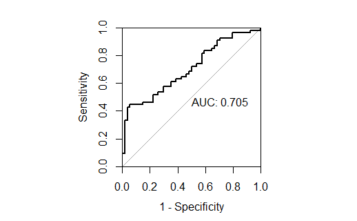

```r
plot(roc(finaltest$explevel, mod1pred[[2]]),direction=">",legacy.axes=TRUE,percent=TRUE,print.auc=TRUE)
```

```r
aucsvm<-auc(roc(finaltest$explevel, mod1pred[[2]]))
#obtain sensitivity and specificity of testing data
predictions <- predict(svm1, newdata = finaltest)
svmcmresult <- confusionMatrix(predictions, finaltest$explevel)
svmsens<-svmcmresult$byClass[1]
svmspecs<-svmcmresult$byClass[2]

#Model 2: Random forest
library(randomForest)
set.seed(123)
rf1<- train(explevel~., data=finaltrain, method='rf',trControl=train_control)
#get AUC of training model
rf1
```

```
Random Forest

440 samples
257 predictors
  2 classes: 'nodep', 'highdep'

No pre-processing
Resampling: Cross-Validated (5 fold, repeated 5 times)
Summary of sample sizes: 352, 352, 352, 352, 352, 352, ...
Resampling results across tuning parameters:

  mtry  ROC        Sens       Spec
    2   0.7663740  0.6581818  0.7427273
  129   0.7697417  0.6472727  0.7581818
  257   0.7696281  0.6509091  0.7581818

ROC was used to select the optimal model using the largest value.
The final value used for the model was mtry = 129.
```

```r
resrf1=as.data.frame(evalm(rf1)$stdres$`Group 1`$Score)[13,]
```

```
***MLeval: Machine Learning Model Evaluation***
Input: caret train function object
Averaging probs.
Group 1 type: repeatedcv
Observations: 440
Number of groups: 1
Observations per group: 440
Positive: highdep
Negative: nodep
Group: Group 1
Positive: 220
Negative: 220
***Performance Metrics***
Group 1 Optimal Informedness = 0.436363636363637
Group 1 AUC-ROC = 0.78
```

```r
#obtain sensitivity and  specificity of training models
sensrf1=as.data.frame(evalm(rf1)$stdres$`Group 1`$Score)[1,]
```

```
***MLeval: Machine Learning Model Evaluation***
Input: caret train function object
Averaging probs.
Group 1 type: repeatedcv
Observations: 440
Number of groups: 1
Observations per group: 440
Positive: highdep
Negative: nodep
Group: Group 1
Positive: 220
Negative: 220
***Performance Metrics***
Group 1 Optimal Informedness = 0.436363636363637
Group 1 AUC-ROC = 0.78
```

```r
specsrf1=as.data.frame(evalm(rf1)$stdres$`Group 1`$Score)[2,]
```

```
***MLeval: Machine Learning Model Evaluation***
Input: caret train function object
Averaging probs.
Group 1 type: repeatedcv
Observations: 440
Number of groups: 1
Observations per group: 440
Positive: highdep
Negative: nodep
Group: Group 1
Positive: 220
Negative: 220
***Performance Metrics***
Group 1 Optimal Informedness = 0.436363636363637
Group 1 AUC-ROC = 0.78
```

```r
#test on testing data
library(pROC)
mod1pred<- predict(rf1, newdata=finaltest,type="prob")
par(pty="s")
par(xaxs = "i", yaxs = "i")
```

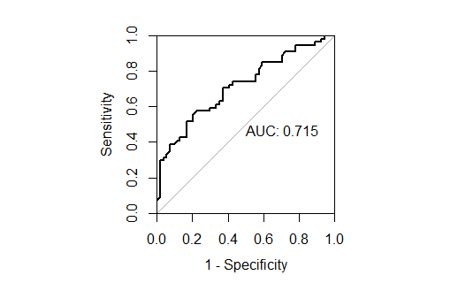

```r
plot(roc(finaltest$explevel, mod1pred[[2]]),direction=">",legacy.axes=TRUE,percent=TRUE,print.auc=TRUE)
```

```r
aucrf<-auc(roc(finaltest$explevel, mod1pred[[2]]))
#obtain sensitivity and specificity of testing data
predictions <- predict(rf1, newdata = finaltest)
rfcmresult <- confusionMatrix(predictions, finaltest$explevel)
rfsens<-rfcmresult$byClass[1]
rfspecs<-rfcmresult$byClass[2]

#Model 3: Gradient boosting machine
library(gbm)
tree1<-train(explevel ~ ., data=finaltrain, method="gbm",trControl=train_control)
#get AUC of training model
tree1
```

```
Stochastic Gradient Boosting

440 samples
257 predictors
  2 classes: 'nodep', 'highdep'

No pre-processing
Resampling: Cross-Validated (5 fold, repeated 5 times)
Summary of sample sizes: 352, 352, 352, 352, 352, 352, ...
Resampling results across tuning parameters:

  interaction.depth  n.trees  ROC        Sens       Spec
  1                   50      0.7339876  0.6727273  0.6772727
  1                  100      0.7486777  0.6890909  0.6845455
  1                  150      0.7538636  0.6972727  0.6863636
  2                   50      0.7482851  0.6745455  0.6890909
  2                  100      0.7552686  0.6972727  0.7000000
  2                  150      0.7493182  0.7054545  0.6827273
  3                   50      0.7508058  0.6909091  0.6936364
  3                  100      0.7462190  0.6881818  0.6927273
  3                  150      0.7416116  0.6881818  0.6690909

Tuning parameter 'shrinkage' was held constant at a value of 0.1
Tuning
 parameter 'n.minobsinnode' was held constant at a value of 10
ROC was used to select the optimal model using the largest value.
The final values used for the model were n.trees = 100, interaction.depth = 2, shrinkage
 = 0.1 and n.minobsinnode = 10.
```

```r
restree1=as.data.frame(evalm(tree1)$stdres$`Group 1`$Score)[13,]
```

```
***MLeval: Machine Learning Model Evaluation***
Input: caret train function object
Averaging probs.
Group 1 type: repeatedcv
Observations: 440
Number of groups: 1
Observations per group: 440
Positive: highdep
Negative: nodep
Group: Group 1
Positive: 220
Negative: 220
***Performance Metrics***
Group 1 Optimal Informedness = 0.45
Group 1 AUC-ROC = 0.77
```

```r
#obtain sensitivity and  specificity of training models
senstree1=as.data.frame(evalm(tree1)$stdres$`Group 1`$Score)[1,]
```

```
***MLeval: Machine Learning Model Evaluation***
Input: caret train function object
Averaging probs.
Group 1 type: repeatedcv
Observations: 440
Number of groups: 1
Observations per group: 440
Positive: highdep
Negative: nodep
Group: Group 1
Positive: 220
Negative: 220
***Performance Metrics***
Group 1 Optimal Informedness = 0.45
Group 1 AUC-ROC = 0.77
```

```r
specstree1=as.data.frame(evalm(tree1)$stdres$`Group 1`$Score)[2,]
```

```
***MLeval: Machine Learning Model Evaluation***
Input: caret train function object
Averaging probs.
Group 1 type: repeatedcv
Observations: 440
Number of groups: 1
Observations per group: 440
Positive: highdep
Negative: nodep
Group: Group 1
Positive: 220
Negative: 220
***Performance Metrics***
Group 1 Optimal Informedness = 0.45
Group 1 AUC-ROC = 0.77
```

```r
#test on testing data
library(pROC)
mod1pred<- predict(tree1, newdata=finaltest,type="prob")
par(pty="s")
par(xaxs = "i", yaxs = "i")
```

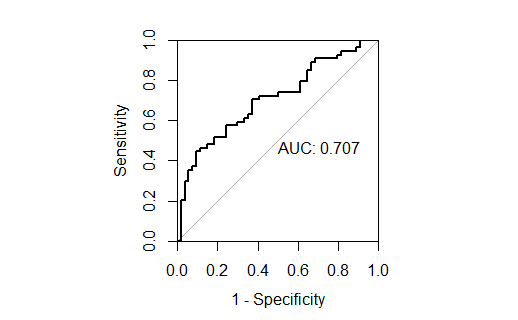

```r
plot(roc(finaltest$explevel, mod1pred[[2]]),direction=">",legacy.axes=TRUE,percent=TRUE,print.auc=TRUE)
```

```r
aucgbm<-auc(roc(finaltest$explevel, mod1pred[[2]]))
#obtain sensitivity and specificity of testing data
predictions <- predict(tree1, newdata = finaltest)
gbmcmresult <- confusionMatrix(predictions, finaltest$explevel)
gbmsens<-gbmcmresult$byClass[1]
gbmspecs<-gbmcmresult$byClass[2]

#Model 4: logistric regression
logreg1 <- train(explevel ~.,  data=finaltrain, method="glm", family="binomial",trControl=train_control,metric = "ROC")
```

[output not shown]

[output cut: 90 more lines]

[output not shown]

```r
#get AUC of training model
logreg1
```

```
Generalized Linear Model

440 samples
257 predictors
  2 classes: 'nodep', 'highdep'

No pre-processing
Resampling: Cross-Validated (5 fold, repeated 5 times)
Summary of sample sizes: 352, 352, 352, 352, 352, 352, ...
Resampling results:

  ROC        Sens       Spec
  0.5218079  0.5463636  0.4927273
```

```r
reslogreg1=as.data.frame(evalm(logreg1)$stdres$`Group 1`$Score)[13,]
```

```
***MLeval: Machine Learning Model Evaluation***
Input: caret train function object
Averaging probs.
Group 1 type: repeatedcv
Observations: 440
Number of groups: 1
Observations per group: 440
Positive: highdep
Negative: nodep
Group: Group 1
Positive: 220
Negative: 220
***Performance Metrics***
Group 1 Optimal Informedness = 0.0772727272727272
Group 1 AUC-ROC = 0.54
```

```r
#obtain sensitivity and  specificity of training models
senslogreg1=as.data.frame(evalm(logreg1)$stdres$`Group 1`$Score)[1,]
```

```
***MLeval: Machine Learning Model Evaluation***
Input: caret train function object
Averaging probs.
Group 1 type: repeatedcv
Observations: 440
Number of groups: 1
Observations per group: 440
Positive: highdep
Negative: nodep
Group: Group 1
Positive: 220
Negative: 220
***Performance Metrics***
Group 1 Optimal Informedness = 0.0772727272727272
Group 1 AUC-ROC = 0.54
```

```r
specslogreg1=as.data.frame(evalm(logreg1)$stdres$`Group 1`$Score)[2,]
```

```
***MLeval: Machine Learning Model Evaluation***
Input: caret train function object
Averaging probs.
Group 1 type: repeatedcv
Observations: 440
Number of groups: 1
Observations per group: 440
Positive: highdep
Negative: nodep
Group: Group 1
Positive: 220
Negative: 220
***Performance Metrics***
Group 1 Optimal Informedness = 0.0772727272727272
Group 1 AUC-ROC = 0.54
```

```r
#test on testing data
library(pROC)
mod1pred<- predict(logreg1, newdata=finaltest,type="prob")
par(pty="s")
par(xaxs = "i", yaxs = "i")
```

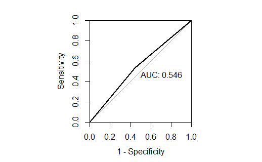

```r
plot(roc(finaltest$explevel, mod1pred[[2]]),direction=">",legacy.axes=TRUE,percent=TRUE,print.auc=TRUE)
```

```r
auclogreg<-auc(roc(finaltest$explevel, mod1pred[[2]]))
#obtain sensitivity and specificity of testing data
predictions <- predict(logreg1, newdata = finaltest)
logregcmresult <- confusionMatrix(predictions, finaltest$explevel)
logregsens<-logregcmresult$byClass[1]
logregspecs<-logregcmresult$byClass[2]

#Model 5: Elastic net
library(glmnet)
elastic1 <- train(explevel ~.,data=finaltrain,method = "glmnet", trControl=train_control,metric = "ROC")

#get AUC of training model
elastic1
```

```
glmnet

440 samples
257 predictors
  2 classes: 'nodep', 'highdep'

No pre-processing
Resampling: Cross-Validated (5 fold, repeated 5 times)
Summary of sample sizes: 352, 352, 352, 352, 352, 352, ...
Resampling results across tuning parameters:

  alpha  lambda        ROC        Sens       Spec
  0.10   0.0002577737  0.6055372  0.5918182  0.5854545
  0.10   0.0025777371  0.6551860  0.6454545  0.6054545
  0.10   0.0257773709  0.7410331  0.7109091  0.6500000
  0.55   0.0002577737  0.6058264  0.6063636  0.5918182
  0.55   0.0025777371  0.6652273  0.6600000  0.6172727
  0.55   0.0257773709  0.7694628  0.7154545  0.6800000
  1.00   0.0002577737  0.5973140  0.6036364  0.5900000
  1.00   0.0025777371  0.6713017  0.6636364  0.6181818
  1.00   0.0257773709  0.7532231  0.7045455  0.6609091

ROC was used to select the optimal model using the largest value.
The final values used for the model were alpha = 0.55 and lambda = 0.02577737.
```

```r
reselastic1=as.data.frame(evalm(elastic1)$stdres$`Group 1`$Score)[13,]
```

```
***MLeval: Machine Learning Model Evaluation***
Input: caret train function object
Averaging probs.
Group 1 type: repeatedcv
Observations: 440
Number of groups: 1
Observations per group: 440
Positive: highdep
Negative: nodep
Group: Group 1
Positive: 220
Negative: 220
***Performance Metrics***
Group 1 Optimal Informedness = 0.422727272727273
Group 1 AUC-ROC = 0.77
```

```r
#obtain sensitivity and  specificity of training models
senselastic1=as.data.frame(evalm(elastic1)$stdres$`Group 1`$Score)[1,]
```

```
***MLeval: Machine Learning Model Evaluation***
Input: caret train function object
Averaging probs.
Group 1 type: repeatedcv
Observations: 440
Number of groups: 1
Observations per group: 440
Positive: highdep
Negative: nodep
Group: Group 1
Positive: 220
Negative: 220
***Performance Metrics***
Group 1 Optimal Informedness = 0.422727272727273
Group 1 AUC-ROC = 0.77
```

```r
specselastic1=as.data.frame(evalm(elastic1)$stdres$`Group 1`$Score)[2,]
```

```
***MLeval: Machine Learning Model Evaluation***
Input: caret train function object
Averaging probs.
Group 1 type: repeatedcv
Observations: 440
Number of groups: 1
Observations per group: 440
Positive: highdep
Negative: nodep
Group: Group 1
Positive: 220
Negative: 220
***Performance Metrics***
Group 1 Optimal Informedness = 0.422727272727273
Group 1 AUC-ROC = 0.77
```

```r
#test on testing data
library(pROC)
mod1pred<- predict(elastic1, newdata=finaltest,type="prob")
par(pty="s")
par(xaxs = "i", yaxs = "i")
```

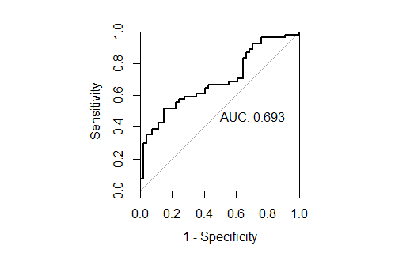

```r
plot(roc(finaltest$explevel, mod1pred[[2]]),direction=">",legacy.axes=TRUE,percent=TRUE,print.auc=TRUE)
```

```r
aucelastic<-auc(roc(finaltest$explevel, mod1pred[[2]]))
#obtain sensitivity and specificity of testing data
predictions <- predict(elastic1, newdata = finaltest)
elasticcmresult <- confusionMatrix(predictions, finaltest$explevel)
elasticsens<-elasticcmresult$byClass[1]
elasticspecs<-elasticcmresult$byClass[2]

#Model 6: Neural network
nn1 <- train(explevel ~.,data=finaltrain,method = "nnet", trControl=train_control,metric = "ROC")
#get AUC of training model
nn1
```

```
Neural Network

440 samples
257 predictors
  2 classes: 'nodep', 'highdep'

No pre-processing
Resampling: Cross-Validated (5 fold, repeated 5 times)
Summary of sample sizes: 352, 352, 352, 352, 352, 352, ...
Resampling results across tuning parameters:

  size  decay  ROC        Sens       Spec
  1     0e+00  0.6117459  0.6018182  0.6072727
  1     1e-04  0.6341529  0.5418182  0.6436364
  1     1e-01  0.6576240  0.6418182  0.5990909
  3     0e+00  0.7002376  0.7654545  0.5809091
  3     1e-04  0.7127169  0.6718182  0.6536364
  3     1e-01  0.7052893  0.6672727  0.6309091
  5     0e+00        NaN        NaN        NaN
  5     1e-04        NaN        NaN        NaN
  5     1e-01        NaN        NaN        NaN

ROC was used to select the optimal model using the largest value.
The final values used for the model were size = 3 and decay = 1e-04.
```

```r
resnn1=as.data.frame(evalm(nn1)$stdres$`Group 1`$Score)[13,]
```

```
***MLeval: Machine Learning Model Evaluation***
Input: caret train function object
Averaging probs.
Group 1 type: repeatedcv
Observations: 440
Number of groups: 1
Observations per group: 440
Positive: highdep
Negative: nodep
Group: Group 1
Positive: 220
Negative: 220
***Performance Metrics***
Group 1 Optimal Informedness = 0.4
Group 1 AUC-ROC = 0.74
```

```r
#obtain sensitivity and  specificity of training models
sensnn1=as.data.frame(evalm(nn1)$stdres$`Group 1`$Score)[1,]
```

```
***MLeval: Machine Learning Model Evaluation***
Input: caret train function object
Averaging probs.
Group 1 type: repeatedcv
Observations: 440
Number of groups: 1
Observations per group: 440
Positive: highdep
Negative: nodep
Group: Group 1
Positive: 220
Negative: 220
***Performance Metrics***
Group 1 Optimal Informedness = 0.4
Group 1 AUC-ROC = 0.74
```

```r
specsnn1=as.data.frame(evalm(nn1)$stdres$`Group 1`$Score)[2,]
```

```
***MLeval: Machine Learning Model Evaluation***
Input: caret train function object
Averaging probs.
Group 1 type: repeatedcv
Observations: 440
Number of groups: 1
Observations per group: 440
Positive: highdep
Negative: nodep
Group: Group 1
Positive: 220
Negative: 220
***Performance Metrics***
Group 1 Optimal Informedness = 0.4
Group 1 AUC-ROC = 0.74
```

```r
#test on testing data
library(pROC)
mod1pred<- predict(nn1, newdata=finaltest,type="prob")
par(pty="s")
par(xaxs = "i", yaxs = "i")
```

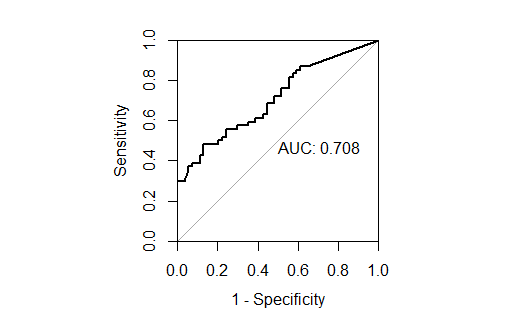

```r
plot(roc(finaltest$explevel, mod1pred[[2]]),direction=">",legacy.axes=TRUE,percent=TRUE,print.auc=TRUE)
```

```r
aucnn<-auc(roc(finaltest$explevel, mod1pred[[2]]))
#obtain sensitivity and specificity of testing data
predictions <- predict(nn1, newdata = finaltest)
nncmresult <- confusionMatrix(predictions, finaltest$explevel)
nnsens<-nncmresult$byClass[1]
nnspecs<-nncmresult$byClass[2]

#combine all results
trainingresult<-data.frame(ressvm1,senssvm1,specssvm1,resnn1,sensnn1,specsnn1,reslogreg1,senslogreg1,specslogreg1,reselastic1,senselastic1,specselastic1,restree1,senstree1,specstree1,resrf1,sensrf1,specsrf1)
colnames(trainingresult)<-c("aucsvm","svmsens","svmspecs","aucnn","nnsens","nnspecs","auclogreg","logregsens","logregspecs","aucelastic","elasticsens","elasticspecs","aucgbm","gbmsens","gbmspecs","aucrf","rfsens","rfspecs")
testingresult<-data.frame(aucsvm,svmsens,svmspecs,aucnn,nnsens,nnspecs,auclogreg,logregsens,logregspecs,aucelastic,elasticsens,elasticspecs,aucgbm,gbmsens,gbmspecs,aucrf,rfsens,rfspecs)
allresult<-rbind(trainingresult,testingresult)
rownames(allresult)<-c("training","testing")

write.csv(allresult,"cnmlresult.csv")
```

#### PCG dataset - Statistical method for feature selection and machine learning prediction model

```r
#split the data
#can change the splitting ratio for this by changing p
set.seed(123)
trainIndex <- createDataPartition(omicsexppcg_cleanv2$explevel, p = .8,list = FALSE)
cTrain <- omicsexppcg_cleanv2[trainIndex,]
cTest  <- omicsexppcg_cleanv2[-trainIndex,]

#check whether datasets are balanced
table(cTrain$explevel)
```

```
highdep   nodep
    200     196
```

```r
table(cTest$explevel)
```

```
highdep   nodep
     49      48
```

```r
#Convert the dataset to a format for stats test
cTrain_v2<-cTrain[,-c(1,2)]
cTrain_v2_t<-data.frame(t(data.matrix(cTrain_v2)))
colnames(cTrain_v2_t) <- cTrain[,2]

#Perform Welch's T-test (Independent T-test) on (log-transformed) normalized data
ttestres<-row_t_welch(cTrain_v2_t[,grepl("nodep", names(cTrain_v2_t))] , cTrain_v2_t[,grepl("highdep", names(cTrain_v2_t))], alternative = "two.sided")
#adjust P value using FDR
ttestres$FDR <- p.adjust(ttestres$pvalue, "BH")

#Calculate Fold change in a new column
ttestres$FC <- 2^(ttestres$mean.x-ttestres$mean.y)

#convert those FC with values smaller than 1 to negative fold change
#for better interpretation/comparison with those FC values>1
ttestres$finalfc <- ifelse(ttestres$FC <1, -1/ttestres$FC,ttestres$FC)

#filter by FDR and finalfc to identify potential biomarkers
fcfilterrna<-ttestres%>%filter(FDR<0.05&abs(finalfc)>=2)
#261 genes

#Obtain dataset that contains the potential biomarkers
train_sigrnaexp<-cTrain_v2_t[rownames(cTrain_v2_t) %in% rownames(fcfilterrna), ]
train_sigrnaexp_t<-data.frame(t(data.matrix(train_sigrnaexp)))
train_sigrnaexp_t<-cbind(cTrain$explevel,train_sigrnaexp_t)
colnames(train_sigrnaexp_t)[1]<-"explevel"

#convert label as factor
train_sigrnaexp_t$explevel <- factor(train_sigrnaexp_t$explevel, levels = c("nodep", "highdep"))

#Remove near zero variance
set.seed(123)
nzv<-nearZeroVar(train_sigrnaexp_t[,-1])
if (length(nzv)!=0) {
  filterednzv <- train_sigrnaexp_t[, -nzv]
} else {
  filterednzv <- train_sigrnaexp_t
}

#Remove columns with NA values
filterednzvna<-filterednzv[, colSums(is.na(filterednzv)) == 0]

#Remove highly correlated pairs
set.seed(123)
descrCor <- cor(filterednzvna[,2:ncol(filterednzvna)])
highCorr <- findCorrelation(descrCor, cutoff=0.9)
if (length(highCorr)!=0) {
  filterednzvnacr <- filterednzvna[, -highCorr]
} else {
  filterednzvnacr <- filterednzvna
}

#rename object as final train
finaltrain<-filterednzvnacr

#extract same variables on test set
finaltest<-cTest %>% select(colnames((filterednzvnacr)))
finaltest$explevel<-factor(finaltest$explevel, levels = c("nodep", "highdep"))

#Second step: Fit data into model
set.seed(123)
train_control <- trainControl(method="repeatedcv", number=5, repeats=5,classProbs = TRUE,summaryFunction = twoClassSummary,savePredictions = TRUE)

#Model 1: SVM
svm1 <- train(explevel ~., finaltrain, method = "svmRadial", trControl = train_control)
svm1
```

```
Support Vector Machines with Radial Basis Function Kernel

396 samples
256 predictors
  2 classes: 'nodep', 'highdep'

No pre-processing
Resampling: Cross-Validated (5 fold, repeated 5 times)
Summary of sample sizes: 317, 317, 316, 317, 317, 317, ...
Resampling results across tuning parameters:

  C     ROC        Sens       Spec
  0.25  0.7760974  0.6661795  0.737
  0.50  0.7851442  0.6551026  0.744
  1.00  0.7837115  0.6876923  0.723

Tuning parameter 'sigma' was held constant at a value of 0.002474651
ROC was used to select the optimal model using the largest value.
The final values used for the model were sigma = 0.002474651 and C = 0.5.
```

```r
#get AUC of training model
ressvm1=as.data.frame(evalm(svm1)$stdres$`Group 1`$Score)[13,]
```

```
***MLeval: Machine Learning Model Evaluation***
Input: caret train function object
Averaging probs.
Group 1 type: repeatedcv
Observations: 396
Number of groups: 1
Observations per group: 396
Positive: highdep
Negative: nodep
Group: Group 1
Positive: 200
Negative: 196
***Performance Metrics***
Group 1 Optimal Informedness = 0.440714285714286
Group 1 AUC-ROC = 0.78
```

```r
#obtain sensitivity and  specificity of training models
senssvm1=as.data.frame(evalm(svm1)$stdres$`Group 1`$Score)[1,]
```

```
***MLeval: Machine Learning Model Evaluation***
Input: caret train function object
Averaging probs.
Group 1 type: repeatedcv
Observations: 396
Number of groups: 1
Observations per group: 396
Positive: highdep
Negative: nodep
Group: Group 1
Positive: 200
Negative: 196
***Performance Metrics***
Group 1 Optimal Informedness = 0.440714285714286
Group 1 AUC-ROC = 0.78
```

```r
specssvm1=as.data.frame(evalm(svm1)$stdres$`Group 1`$Score)[2,]
```

```
***MLeval: Machine Learning Model Evaluation***
Input: caret train function object
Averaging probs.
Group 1 type: repeatedcv
Observations: 396
Number of groups: 1
Observations per group: 396
Positive: highdep
Negative: nodep
Group: Group 1
Positive: 200
Negative: 196
***Performance Metrics***
Group 1 Optimal Informedness = 0.440714285714286
Group 1 AUC-ROC = 0.78
```

```r
#test on testing data
library(pROC)
mod1pred<- predict(svm1, newdata=finaltest,type="prob")
par(pty="s")
par(xaxs = "i", yaxs = "i")
```

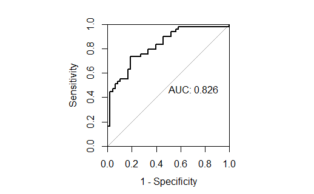

```r
plot(roc(finaltest$explevel, mod1pred[[2]]),direction=">",legacy.axes=TRUE,percent=TRUE,print.auc=TRUE)
```

```r
aucsvm<-auc(roc(finaltest$explevel, mod1pred[[2]]))
#obtain sensitivity and specificity of testing data
predictions <- predict(svm1, newdata = finaltest)
svmcmresult <- confusionMatrix(predictions, finaltest$explevel)
svmsens<-svmcmresult$byClass[1]
svmspecs<-svmcmresult$byClass[2]

#Model 2: Random forest
library(randomForest)
set.seed(123)
rf1<- train(explevel~., data=finaltrain, method='rf',trControl=train_control)
#get AUC of training model
rf1
```

```
Random Forest

396 samples
256 predictors
  2 classes: 'nodep', 'highdep'

No pre-processing
Resampling: Cross-Validated (5 fold, repeated 5 times)
Summary of sample sizes: 317, 317, 316, 317, 317, 317, ...
Resampling results across tuning parameters:

  mtry  ROC        Sens       Spec
    2   0.7801625  0.6653077  0.735
  129   0.7860135  0.6817436  0.720
  256   0.7866647  0.6888974  0.724

ROC was used to select the optimal model using the largest value.
The final value used for the model was mtry = 256.
```

```r
resrf1=as.data.frame(evalm(rf1)$stdres$`Group 1`$Score)[13,]
```

```
***MLeval: Machine Learning Model Evaluation***
Input: caret train function object
Averaging probs.
Group 1 type: repeatedcv
Observations: 396
Number of groups: 1
Observations per group: 396
Positive: highdep
Negative: nodep
Group: Group 1
Positive: 200
Negative: 196
***Performance Metrics***
Group 1 Optimal Informedness = 0.439285714285714
Group 1 AUC-ROC = 0.79
```

```r
#obtain sensitivity and  specificity of training models
sensrf1=as.data.frame(evalm(rf1)$stdres$`Group 1`$Score)[1,]
```

```
***MLeval: Machine Learning Model Evaluation***
Input: caret train function object
Averaging probs.
Group 1 type: repeatedcv
Observations: 396
Number of groups: 1
Observations per group: 396
Positive: highdep
Negative: nodep
Group: Group 1
Positive: 200
Negative: 196
***Performance Metrics***
Group 1 Optimal Informedness = 0.439285714285714
Group 1 AUC-ROC = 0.79
```

```r
specsrf1=as.data.frame(evalm(rf1)$stdres$`Group 1`$Score)[2,]
```

```
***MLeval: Machine Learning Model Evaluation***
Input: caret train function object
Averaging probs.
Group 1 type: repeatedcv
Observations: 396
Number of groups: 1
Observations per group: 396
Positive: highdep
Negative: nodep
Group: Group 1
Positive: 200
Negative: 196
***Performance Metrics***
Group 1 Optimal Informedness = 0.439285714285714
Group 1 AUC-ROC = 0.79
```

```r
#test on testing data
library(pROC)
mod1pred<- predict(rf1, newdata=finaltest,type="prob")
par(pty="s")
par(xaxs = "i", yaxs = "i")
```

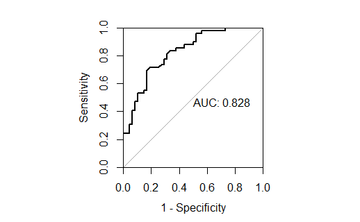

```r
plot(roc(finaltest$explevel, mod1pred[[2]]),direction=">",legacy.axes=TRUE,percent=TRUE,print.auc=TRUE)
```

```r
aucrf<-auc(roc(finaltest$explevel, mod1pred[[2]]))
#obtain sensitivity and specificity of testing data
predictions <- predict(rf1, newdata = finaltest)
rfcmresult <- confusionMatrix(predictions, finaltest$explevel)
rfsens<-rfcmresult$byClass[1]
rfspecs<-rfcmresult$byClass[2]

#Model 3: Gradient boosting machine
library(gbm)
tree1<-train(explevel ~ ., data=finaltrain, method="gbm",trControl=train_control)
#get AUC of training model
tree1
```

```
Stochastic Gradient Boosting

396 samples
256 predictors
  2 classes: 'nodep', 'highdep'

No pre-processing
Resampling: Cross-Validated (5 fold, repeated 5 times)
Summary of sample sizes: 317, 317, 317, 316, 317, 317, ...
Resampling results across tuning parameters:

  interaction.depth  n.trees  ROC        Sens       Spec
  1                   50      0.7724064  0.6717949  0.710
  1                  100      0.7775609  0.6922051  0.719
  1                  150      0.7760333  0.6951795  0.721
  2                   50      0.7729968  0.6870769  0.708
  2                  100      0.7681526  0.6888974  0.708
  2                  150      0.7625801  0.6908974  0.700
  3                   50      0.7745109  0.6757949  0.715
  3                  100      0.7671038  0.6932308  0.704
  3                  150      0.7610923  0.6890769  0.701

Tuning parameter 'shrinkage' was held constant at a value of 0.1
Tuning
 parameter 'n.minobsinnode' was held constant at a value of 10
ROC was used to select the optimal model using the largest value.
The final values used for the model were n.trees = 100, interaction.depth = 1, shrinkage
 = 0.1 and n.minobsinnode = 10.
```

```r
restree1=as.data.frame(evalm(tree1)$stdres$`Group 1`$Score)[13,]
```

```
***MLeval: Machine Learning Model Evaluation***
Input: caret train function object
Averaging probs.
Group 1 type: repeatedcv
Observations: 396
Number of groups: 1
Observations per group: 396
Positive: highdep
Negative: nodep
Group: Group 1
Positive: 200
Negative: 196
***Performance Metrics***
Group 1 Optimal Informedness = 0.471428571428572
Group 1 AUC-ROC = 0.79
```

```r
#obtain sensitivity and  specificity of training models
senstree1=as.data.frame(evalm(tree1)$stdres$`Group 1`$Score)[1,]
```

```
***MLeval: Machine Learning Model Evaluation***
Input: caret train function object
Averaging probs.
Group 1 type: repeatedcv
Observations: 396
Number of groups: 1
Observations per group: 396
Positive: highdep
Negative: nodep
Group: Group 1
Positive: 200
Negative: 196
***Performance Metrics***
Group 1 Optimal Informedness = 0.471428571428572
Group 1 AUC-ROC = 0.79
```

```r
specstree1=as.data.frame(evalm(tree1)$stdres$`Group 1`$Score)[2,]
```

```
***MLeval: Machine Learning Model Evaluation***
Input: caret train function object
Averaging probs.
Group 1 type: repeatedcv
Observations: 396
Number of groups: 1
Observations per group: 396
Positive: highdep
Negative: nodep
Group: Group 1
Positive: 200
Negative: 196
***Performance Metrics***
Group 1 Optimal Informedness = 0.471428571428572
Group 1 AUC-ROC = 0.79
```

```r
#test on testing data
library(pROC)
mod1pred<- predict(tree1, newdata=finaltest,type="prob")
par(pty="s")
par(xaxs = "i", yaxs = "i")
```

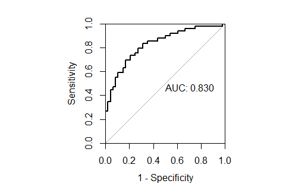

```r
plot(roc(finaltest$explevel, mod1pred[[2]]),direction=">",legacy.axes=TRUE,percent=TRUE,print.auc=TRUE)
```

```r
aucgbm<-auc(roc(finaltest$explevel, mod1pred[[2]]))
#obtain sensitivity and specificity of testing data
predictions <- predict(tree1, newdata = finaltest)
gbmcmresult <- confusionMatrix(predictions, finaltest$explevel)
gbmsens<-gbmcmresult$byClass[1]
gbmspecs<-gbmcmresult$byClass[2]

#Model 4: logistric regression model
logreg1 <- train(explevel ~.,  data=finaltrain, method="glm", family="binomial",trControl=train_control,metric = "ROC")
```

[output not shown]

```r
#get AUC of training model
logreg1
```

```
Generalized Linear Model

396 samples
256 predictors
  2 classes: 'nodep', 'highdep'

No pre-processing
Resampling: Cross-Validated (5 fold, repeated 5 times)
Summary of sample sizes: 317, 317, 317, 316, 317, 317, ...
Resampling results:

  ROC        Sens       Spec
  0.5730538  0.5795385  0.555
```

```r
reslogreg1=as.data.frame(evalm(logreg1)$stdres$`Group 1`$Score)[13,]
```

```
***MLeval: Machine Learning Model Evaluation***
Input: caret train function object
Averaging probs.
Group 1 type: repeatedcv
Observations: 396
Number of groups: 1
Observations per group: 396
Positive: highdep
Negative: nodep
Group: Group 1
Positive: 200
Negative: 196
***Performance Metrics***
Group 1 Optimal Informedness = 0.214897959183673
Group 1 AUC-ROC = 0.62
```

```r
#obtain sensitivity and  specificity of training models
senslogreg1=as.data.frame(evalm(logreg1)$stdres$`Group 1`$Score)[1,]
```

```
***MLeval: Machine Learning Model Evaluation***
Input: caret train function object
Averaging probs.
Group 1 type: repeatedcv
Observations: 396
Number of groups: 1
Observations per group: 396
Positive: highdep
Negative: nodep
Group: Group 1
Positive: 200
Negative: 196
***Performance Metrics***
Group 1 Optimal Informedness = 0.214897959183673
Group 1 AUC-ROC = 0.62
```

```r
specslogreg1=as.data.frame(evalm(logreg1)$stdres$`Group 1`$Score)[2,]
```

```
***MLeval: Machine Learning Model Evaluation***
Input: caret train function object
Averaging probs.
Group 1 type: repeatedcv
Observations: 396
Number of groups: 1
Observations per group: 396
Positive: highdep
Negative: nodep
Group: Group 1
Positive: 200
Negative: 196
***Performance Metrics***
Group 1 Optimal Informedness = 0.214897959183673
Group 1 AUC-ROC = 0.62
```

```r
#test on testing data
library(pROC)
mod1pred<- predict(logreg1, newdata=finaltest,type="prob")
par(pty="s")
par(xaxs = "i", yaxs = "i")
```

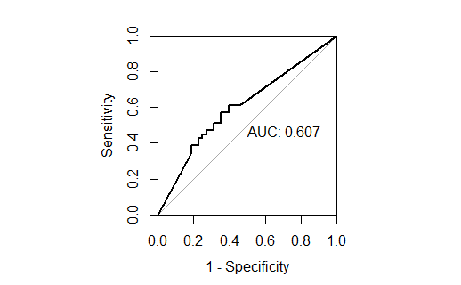

```r
plot(roc(finaltest$explevel, mod1pred[[2]]),direction=">",legacy.axes=TRUE,percent=TRUE,print.auc=TRUE)
```

```r
auclogreg<-auc(roc(finaltest$explevel, mod1pred[[2]]))
#obtain sensitivity and specificity of testing data
predictions <- predict(logreg1, newdata = finaltest)
logregcmresult <- confusionMatrix(predictions, finaltest$explevel)
logregsens<-logregcmresult$byClass[1]
logregspecs<-logregcmresult$byClass[2]

#Model 5: Elastic net
library(glmnet)
elastic1 <- train(explevel ~.,data=finaltrain,method = "glmnet", trControl=train_control,metric = "ROC")

#get AUC of training model
elastic1
```

```
glmnet

396 samples
256 predictors
  2 classes: 'nodep', 'highdep'

No pre-processing
Resampling: Cross-Validated (5 fold, repeated 5 times)
Summary of sample sizes: 317, 317, 317, 317, 316, 316, ...
Resampling results across tuning parameters:

  alpha  lambda        ROC        Sens       Spec
  0.10   0.0003884167  0.7029269  0.6532051  0.653
  0.10   0.0038841666  0.7182103  0.6624359  0.666
  0.10   0.0388416664  0.7659224  0.7051026  0.707
  0.55   0.0003884167  0.6980622  0.6501282  0.656
  0.55   0.0038841666  0.7144756  0.6542051  0.666
  0.55   0.0388416664  0.8111692  0.7183846  0.734
  1.00   0.0003884167  0.6862494  0.6358205  0.639
  1.00   0.0038841666  0.7147603  0.6592821  0.671
  1.00   0.0388416664  0.8123365  0.7122821  0.743

ROC was used to select the optimal model using the largest value.
The final values used for the model were alpha = 1 and lambda = 0.03884167.
```

```r
reselastic1=as.data.frame(evalm(elastic1)$stdres$`Group 1`$Score)[13,]
```

```
***MLeval: Machine Learning Model Evaluation***
Input: caret train function object
Averaging probs.
Group 1 type: repeatedcv
Observations: 396
Number of groups: 1
Observations per group: 396
Positive: highdep
Negative: nodep
Group: Group 1
Positive: 200
Negative: 196
***Performance Metrics***
Group 1 Optimal Informedness = 0.503265306122449
Group 1 AUC-ROC = 0.81
```

```r
#obtain sensitivity and  specificity of training models
senselastic1=as.data.frame(evalm(elastic1)$stdres$`Group 1`$Score)[1,]
```

```
***MLeval: Machine Learning Model Evaluation***
Input: caret train function object
Averaging probs.
Group 1 type: repeatedcv
Observations: 396
Number of groups: 1
Observations per group: 396
Positive: highdep
Negative: nodep
Group: Group 1
Positive: 200
Negative: 196
***Performance Metrics***
Group 1 Optimal Informedness = 0.503265306122449
Group 1 AUC-ROC = 0.81
```

```r
specselastic1=as.data.frame(evalm(elastic1)$stdres$`Group 1`$Score)[2,]
```

```
***MLeval: Machine Learning Model Evaluation***
Input: caret train function object
Averaging probs.
Group 1 type: repeatedcv
Observations: 396
Number of groups: 1
Observations per group: 396
Positive: highdep
Negative: nodep
Group: Group 1
Positive: 200
Negative: 196
***Performance Metrics***
Group 1 Optimal Informedness = 0.503265306122449
Group 1 AUC-ROC = 0.81
```

```r
#test on testing data
library(pROC)
mod1pred<- predict(elastic1, newdata=finaltest,type="prob")
par(pty="s")
par(xaxs = "i", yaxs = "i")
```

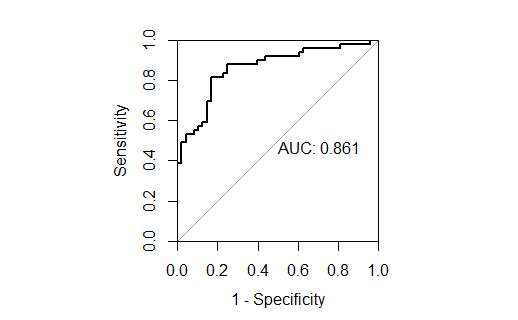

```r
plot(roc(finaltest$explevel, mod1pred[[2]]),direction=">",legacy.axes=TRUE,percent=TRUE,print.auc=TRUE)
```

```r
aucelastic<-auc(roc(finaltest$explevel, mod1pred[[2]]))
#obtain sensitivity and specificity of testing data
predictions <- predict(elastic1, newdata = finaltest)
elasticcmresult <- confusionMatrix(predictions, finaltest$explevel)
elasticsens<-elasticcmresult$byClass[1]
elasticspecs<-elasticcmresult$byClass[2]

#Model 6: Neural network
nn1 <- train(explevel ~.,data=finaltrain,method = "nnet", trControl=train_control,metric = "ROC")
#get AUC of training model
nn1
```

```
Neural Network

396 samples
256 predictors
  2 classes: 'nodep', 'highdep'

No pre-processing
Resampling: Cross-Validated (5 fold, repeated 5 times)
Summary of sample sizes: 317, 317, 316, 317, 317, 317, ...
Resampling results across tuning parameters:

  size  decay  ROC        Sens       Spec
  1     0e+00  0.6582994  0.5678718  0.707
  1     1e-04  0.6404792  0.4569744  0.794
  1     1e-01  0.7226830  0.6273846  0.691
  3     0e+00  0.7333304  0.6705128  0.695
  3     1e-04  0.7313766  0.6386154  0.719
  3     1e-01  0.7138429  0.6233077  0.687
  5     0e+00        NaN        NaN    NaN
  5     1e-04        NaN        NaN    NaN
  5     1e-01        NaN        NaN    NaN

ROC was used to select the optimal model using the largest value.
The final values used for the model were size = 3 and decay = 0.
```

```r
resnn1=as.data.frame(evalm(nn1)$stdres$`Group 1`$Score)[13,]
```

```
***MLeval: Machine Learning Model Evaluation***
Input: caret train function object
Averaging probs.
Group 1 type: repeatedcv
Observations: 396
Number of groups: 1
Observations per group: 396
Positive: highdep
Negative: nodep
Group: Group 1
Positive: 200
Negative: 196
***Performance Metrics***
Group 1 Optimal Informedness = 0.431428571428571
Group 1 AUC-ROC = 0.77
```

```r
#obtain sensitivity and  specificity of training models
sensnn1=as.data.frame(evalm(nn1)$stdres$`Group 1`$Score)[1,]
```

```
***MLeval: Machine Learning Model Evaluation***
Input: caret train function object
Averaging probs.
Group 1 type: repeatedcv
Observations: 396
Number of groups: 1
Observations per group: 396
Positive: highdep
Negative: nodep
Group: Group 1
Positive: 200
Negative: 196
***Performance Metrics***
Group 1 Optimal Informedness = 0.431428571428571
Group 1 AUC-ROC = 0.77
```

```r
specsnn1=as.data.frame(evalm(nn1)$stdres$`Group 1`$Score)[2,]
```

```
***MLeval: Machine Learning Model Evaluation***
Input: caret train function object
Averaging probs.
Group 1 type: repeatedcv
Observations: 396
Number of groups: 1
Observations per group: 396
Positive: highdep
Negative: nodep
Group: Group 1
Positive: 200
Negative: 196
***Performance Metrics***
Group 1 Optimal Informedness = 0.431428571428571
Group 1 AUC-ROC = 0.77
```

```r
#test on testing data
library(pROC)
mod1pred<- predict(nn1, newdata=finaltest,type="prob")
par(pty="s")
par(xaxs = "i", yaxs = "i")
```

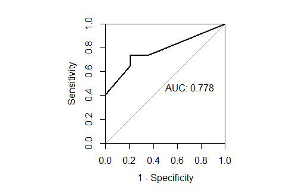

```r
plot(roc(finaltest$explevel, mod1pred[[2]]),direction=">",legacy.axes=TRUE,percent=TRUE,print.auc=TRUE)
```

```r
aucnn<-auc(roc(finaltest$explevel, mod1pred[[2]]))
#obtain sensitivity and specificity of testing data
predictions <- predict(nn1, newdata = finaltest)
nncmresult <- confusionMatrix(predictions, finaltest$explevel)
nnsens<-nncmresult$byClass[1]
nnspecs<-nncmresult$byClass[2]

#combine all results
trainingresult<-data.frame(ressvm1,senssvm1,specssvm1,resnn1,sensnn1,specsnn1,reslogreg1,senslogreg1,specslogreg1,reselastic1,senselastic1,specselastic1,restree1,senstree1,specstree1,resrf1,sensrf1,specsrf1)
colnames(trainingresult)<-c("aucsvm","svmsens","svmspecs","aucnn","nnsens","nnspecs","auclogreg","logregsens","logregspecs","aucelastic","elasticsens","elasticspecs","aucgbm","gbmsens","gbmspecs","aucrf","rfsens","rfspecs")
testingresult<-data.frame(aucsvm,svmsens,svmspecs,aucnn,nnsens,nnspecs,auclogreg,logregsens,logregspecs,aucelastic,elasticsens,elasticspecs,aucgbm,gbmsens,gbmspecs,aucrf,rfsens,rfspecs)
allresult<-rbind(trainingresult,testingresult)
rownames(allresult)<-c("training","testing")

write.csv(allresult,"pcgmlresult.csv")
```